# OpenCLeaR Introduction: From Vector Addition to Multi-Epoch Neural Network Training

OpenCLeaR Developer

2026-11-13

# Introduction to OpenCLeaR

This document serves as a comprehensive guide and architectural reference for the OpenCLeaR framework. We step sequentially through three stages of workload density – from simple element-wise operations to single-step back-propagation gradients, and finally to a completely enclosed multi-epoch neural network training loop. This structure highlights how data persistence and JIT-caching eliminate bus bottlenecks and maximize the parallel performance of OpenCL devices, in this case a mobile Nvidia RTX 4080.

# Part 1: The ‘Hello World’ Example of Parallel Computing (Sigmoid Vector Addition)

We begin with an element-wise addition of two vectors $a$ and $b$ into a target vector $c$, followed by a logistic sigmoid transformation. This minimal functional setup demonstrates how OpenCLeaR links external mathematical dependencies (math_lib) and interfaces vectors.

## Section 1.1: Generating Shared Mathematical Helpers

The math helper library acts as a static compile-time baseline. It provides inline functions for the forward logistic sigmoid transformation and its corresponding analytical first-order derivative used during the gradient backpropagation phase.

```r
libkernel_src <- '
static inline real compute_sigmoid(real x) {
    return (real)1.0f / ((real)1.0f + exp(-x));
}
'
writeLines(libkernel_src, "./libkernel.cl")
```

Note that we use an abstract ‘real’ type instead of ‘float’ or ‘double’ it will be replaced with the appropriate floating point type depending on the capability of your OpenCL device later on the fly. Also note that we write floating point constants as ‘(real)1.0f’ forcing them into the right format avoiding compiler warnings about ‘double’ constants appearing in a ‘float’ only environment.

Furthermore the function is defined as ‘static inline’ which instructs the OpenCL compiler built into your OpenCL driver to only include this function if it is actually call by one of your kernels. This is important because OpenCL binaries are not dynamically linked as you may be accustomed to by your C/C++ experience otherwise.

## Section 1.2: Generating the Element-Wise OpenCL Kernel

The kernel distributes the element-wise addition with application of the sigmoid function across uniform global 1D execution pipelines. Each execution thread resolves its matching array coordinates using its unique worker index, accumulates the vector points, and saves the output directly into the global result vector.

```r
vector_kernel_src <- '
__kernel void sigmoid_add_kernel(__global const real* a,
                                 __global const real* b,
                                 __global real* c,
                                 const int n) {
    int id = get_global_id(0);
    if (id < n) {
        real sum = a[id] + b[id];
        c[id] = compute_sigmoid(sum);
    }
}
'
writeLines(vector_kernel_src, "./sigmoid_add_kernel.cl")
```

This kernel is again written to the working directory and referenced later as ‘./sigmoid_add_kernel.cl’. If we reference it as ‘sigmoid_add_kernel.cl’ without leading ‘./’ it will be read by ‘oclFunction’ from ‘system.file(“kernel”, package = “OpenCLeaR”)’ in the same way as the helper library.

## Section 1.3: Creating the Host-Device Rcpp Vector Interface

The host interface configures the memory transactions for the argument vectors passed from R. It marshals host-allocated memory streams into low-level OpenCL memory nodes, commands synchronous write passes to device global VRAM, schedules the linear kernel execution grid, and pulls the output back to host addresses.

Further down we will declare the arguments ‘a’ and ‘b’ in the call signature of our function as follows:

```r
signature(a = "numeric", b = "numeric")
```

So in the first two lines of of the following C++ interface code we grab these two arguments and store them onto ‘NumericVector’ variables ‘r_a’ and ‘r_b’:

```r
vector_interface_src <- '
NumericVector r_a(a);
NumericVector r_b(b);
```

Now we create a ‘NumericVector’ ‘r_c’ in appropriate size to carry the output vector:

```r
int n = r_a.size();
NumericVector r_c(n);
```

In the following step we create ‘Memory’ objects to carry both the host and device memory. Note that you would have to write a whole bunch of low level CL calls to accomplish this:

```r
Memory<real> gpu_a(*device, n);
Memory<real> gpu_b(*device, n);
Memory<real> gpu_c(*device, n);
```

We have to write our input vectors ‘r_a’ and ‘r_b’ into their ‘Memory’ counterparts ‘gpu_a’ and ‘gpu_b’:

```r
for(int i = 0; i < n; ++i) {
    gpu_a[i] = r_a[i];
    gpu_b[i] = r_b[i];
}
```

The next beautiful feature of using the OpenCL Wrapper classes is the simplicity of transferring the host memory to the device memory.

```r
gpu_a.write_to_device();
gpu_b.write_to_device();
```

Now we declare our kernel with its name and arguments. The ’*device’ pointer used here is prepared by ‘oclFunction’ and ‘inlineCL’ and references to a ready to use OpenCL ‘Device’ object.

```r
Kernel k(*device, (ulong)n, "sigmoid_add_kernel", gpu_a, gpu_b, gpu_c, n);
```

Finally we can execute our kernel

```r
k.run();
```

and transfer the device memory of the result variable ‘gpu_c’ back in read it in the Rcpp result vector ‘r_c’.

```r
gpu_c.read_from_device();
for(int i = 0; i < n; ++i) {
    r_c[i] = gpu_c[i];
}
return r_c;
```

Now lets put this all together and save it as ‘./sigmoid_add_rcpp.cpp’

```r
vector_interface_src <- '
NumericVector r_a(a);
NumericVector r_b(b);

int n = r_a.size();
NumericVector r_c(n);

Memory<real> gpu_a(*device, n);
Memory<real> gpu_b(*device, n);
Memory<real> gpu_c(*device, n);

for(int i = 0; i < n; ++i) {
    gpu_a[i] = r_a[i];
    gpu_b[i] = r_b[i];
}

gpu_a.write_to_device();
gpu_b.write_to_device();

Kernel k(*device, (ulong)n, "sigmoid_add_kernel", gpu_a, gpu_b, gpu_c, n);
k.run();

gpu_c.read_from_device();
for(int i = 0; i < n; ++i) {
    r_c[i] = gpu_c[i];
}

return r_c;
'
writeLines(vector_interface_src, "./sigmoid_add_rcpp.cpp")
```

The same logic with file search applies here: ‘./sigmoid_add_rcpp.cpp’ will be searched for locally, ‘sigmoid_add_rcpp.cpp’ will be read from a subdirectory ‘interface’ at the installed library path, in this case ‘system.file(“interface”, package = “OpenCLeaR”)’.

## Section 1.4: Building the JIT compiled OpenCL R function

Now we stitch the two parts above together via ‘oclFunction’. Its call needs the aforementioned call signature and the file paths to a kernel,an interface and an optional mathematical library. I f the latter is omitted the ‘system’ library ‘libkernel.cl’ sitting at ‘system.file(“kernel”, package = “OpenCLeaR”)’ will be used. Remember that only functions which are really called at least once will be included in the OpenCL binary as they all are declared ‘static inline’-

Furthermore note that we embed the ‘OpenCLeaR::oclFunction’ into a IIEF (Immediately Invoked Function Expression, the ‘(function(){…})()’ construct) R wrapper using lexical scoping which makes it possible for this function to go into your own R library as other R functions, you can prepend a roxygen header containing your documentation, roxygen will recognize it as function to be exported into your NAMESPACE on so on.

You can look at the ‘runifOCL()’ functions in the source to learn how you can use this wrapping mechanism to cache the result of the ‘inlineCL’ compilation step.

```r
sigmoid_vector_gpu <- (function() {
    .vector_gpu_internal <- NULL
    function(vec_x, vec_y) {
        if (is.null(.vector_gpu_internal)) {
            .vector_gpu_internal <<- OpenCLeaR::oclFunction(
                signature      = signature(a = "numeric", b = "numeric"),
                kernel_file    = "./sigmoid_add_kernel.cl",
                interface_file = "./sigmoid_add_rcpp.cpp",
                math_lib       = "./libkernel.cl"
                )
        }
        return(.vector_gpu_internal(a = vec_x, b = vec_y))
    }
})()
```

## Section 1.5: Compiling and Benchmarking Vector Workloads

First initialize OpenCL and choose a device, here device 0, a Nvidia GPU:

```r
GetDeviceList()
```

```
## |----------------.------------------------------------------------------------|
## | Device Index   | Device Name                                   | FP64       |
## |----------------+-----------------------------------------------+------------|
## |     0          | NVIDIA GeForce RTX 4080 Laptop GPU            | yes        |
## |     1          | Intel(R) Iris(R) Xe Graphics                  | no         |
## |     2          | cpu-haswell-13th Gen Intel(R) Core(TM) i9-139 | yes        |
## |----------------'------------------------------------------------------------|
```

```r
ActivateDevice(0)
```

```
## [1] TRUE
```

```r
GetActiveDeviceInfo()
```

```
## |----------------.------------------------------------------------------------|
## | Device Index   | 0                                                          |
## | Platform ID    | 0                                                          |
## | Device ID      | 0                                                          |
## | Device Name    | NVIDIA GeForce RTX 4080 Laptop GPU                         |
## | Device Vendor  | NVIDIA Corporation                                         |
## | Device Driver  | 615.71.09 (Linux)                                          |
## | OpenCL Version | OpenCL C 3.0                                               |
## | Compute Units  | 58 at 1350 MHz (7424 cores, 20.045 TFLOPs/s)               |
## | Memory, Cache  | 11956 MB VRAM, 1624 KB global / 48 KB local                |
## | Buffer Limits  | 2989 MB global, 64 KB constant                             |
## | FP64 capable   | TRUE                                                       |
## |----------------'------------------------------------------------------------|
```

The baseline execution pass verifies device activation states and mounts the foundational vector runtime environments. High-volume vector payloads are tested against standard R environments to isolate JIT compilation delays from real compute processing times.

```r
N_vec <- 5000000L
set.seed(123)
vec_a <- runif(N_vec, -3, 3)
vec_b <- runif(N_vec, -3, 3)

start_cpu_vec <- Sys.time()
res_cpu_vec <- 1 / (1 + exp(-(vec_a + vec_b)))
end_cpu_vec <- Sys.time()
time_cpu_vec <- as.numeric(difftime(end_cpu_vec, start_cpu_vec, units = "secs"))

silent_warmup_vec <- sigmoid_vector_gpu(vec_a[1:10], vec_b[1:10])
```

```
##  [OpenCLeaR Runtime] hardware change or float/double mode change detected! recompile ...
## 🔄 [CRITICAL-DEBUG] /home/alge/R/x86_64-pc-linux-gnu-library/4.6/OpenCLeaR/bin/ocl_compiler -k . -i ././sigmoid_add_kernel.cl -c ./.cl_cache -p 0 -d 0 -l /home/alge/Documents/Projekte/OpenCL-Work/OpenCLeaR/vignettes/libkernel.cl
```

```r
start_gpu_vec <- Sys.time()
res_gpu_vec <- sigmoid_vector_gpu(vec_a, vec_b)
end_gpu_vec <- Sys.time()
time_gpu_vec <- as.numeric(difftime(end_gpu_vec, start_gpu_vec, units = "secs"))

max_diff_vec <- max(abs(res_cpu_vec - res_gpu_vec))
cat("📊 Vector Maximum Discrepancy:", max_diff_vec, "\n")
```

```
## 📊 Vector Maximum Discrepancy: 2.220446e-16
```

```r
cat("⏱️ CPU Vector Time:", round(time_cpu_vec, 4), "s\n")
```

```
## ⏱️ CPU Vector Time: 0.0673 s
```

```r
cat("⏱️ GPU Vector Time:", round(time_gpu_vec, 4), "s (Speedup:", round(time_cpu_vec / time_gpu_vec, 2), "x)\n")
```

```
## ⏱️ GPU Vector Time: 0.0722 s (Speedup: 0.93 x)
```

In this example the parallel processing overhead of shifting memory forth and back between host and device diminishes the speed gain from OpenCL. Of course this depends on the hardware used to execute this example: on some hardware OpenCL is faster on other hardware it is slower than your CPU. To see real speed gains we have to switch to some more realistic examples then one.

## Section 1.6: Key OpenCL Design Principles Applied So Far

Before scaling up to multi-dimensional matrix operations in Part 2, let us review the core GPGPU constraints we already applied in our element-wise example—and one crucial rule we will need next:

- **The `real` Abstraction Layer (Applied in `libkernel.cl` & `sigmoid_add_kernel.cl`):** We avoided raw `float` or `double` declarations in our kernels and Rcpp interfaces. Instead, `OpenCLeaR` defines `real` dynamically at compile time based on the active device’s `FP64` capability, allowing the exact same code to run on both double-capable GPUs and single-precision hardware.
- **Explicit Constant Literals (Applied in `compute_sigmoid`):** We explicitly cast and suffixed scalar constants as `(real)1.0f`. Uncasted literals like `1.0` default to 64-bit `double` in OpenCL C, which either triggers slow software emulation or causes compilation failures on pure single-precision (`FP32`) devices.
- **Memory Coalescing (Applied in `Y[id]` / `c[id]`):** Adjacent threads (`id = get_global_id(0)`) read and write contiguous memory addresses (`a[id]`, `b[id]`, `c[id]`). This allows the GPU memory controller to bundle parallel memory transactions into unified cache bursts.
- **Minimal Branch Divergence (Applied in `if (id < n)`):** Inside GPU warps/wavefronts, threads execute in lock-step. Aside from the single boundary guard `if (id < n)` at the end of the grid, our kernel avoids nested `if-else` branches so no worker threads sit idle.
- **Explicit Memory Space Boundaries (Applied in Kernel Signatures):** OpenCL strictly separates memory pools (`__global` for main device VRAM, `__local` for fast work-group scratchpad memory, and `__private` for thread-local registers). In Part 1, all array pointers were explicitly qualified as `__global`.
- **Preparing for Part 2 – Column-Major Matrix Layout:** R stores matrices column by column. When mapping 2D matrices onto a flat 1D thread grid (`id = get_global_id(0)`) in the upcoming dense layer kernels, consecutive threads must step down rows first (`row = id % num_samples`, `col = id / num_samples`) with matching index offsets (`k * num_samples + row`) to preserve memory coalescing.

# Part 2: Scaling Up (Neural Network Single-Step Backpropagation)

To unlock the streaming multiprocessors, we increase architectural intensity to O(N³) by implementing a dense neural layer forward pass followed immediately by analytical backpropagation to isolate input error (Δ X), weight gradients (Δ W), and bias updates (Δ b).

## Section 2.1: Generating the Forward Passage Kernel

The forward pass kernel maps the input transformations across the global execution thread grid. It calculates the linear activation of the dense layer by computing the inner product of the input matrices, injects the corresponding bias vector components, and maps the output matrix elements directly through the logistic activation function.

Note that we now execute the complete sum on a single compute node, the previous example we distributed the sum across all compute nodes. But in contrast to the previous example we compute now all weighted sums for a complete neural network in parallel. Each compute node represents a single neuron of our neural net.

```r
nn_kernels_src <- '
__kernel void dense_forward_kernel(__global const real* X,
                                 __global const real* W,
                                 __global const real* b,
                                 __global real* Y,
                                 const int num_samples,
                                 const int in_features,
                                 const int out_features) {
    int id = get_global_id(0);
    int total_elements = num_samples * out_features;

    if (id < total_elements) {
        int row = id % num_samples;
        int col = id / num_samples;

        real sum = (real)0.0f;
        for (int k = 0; k < in_features; ++k) {
            sum += X[k * num_samples + row] * W[col * in_features + k];
        }
        sum += b[col];
        Y[id] = compute_sigmoid(sum);
    }
}
'
writeLines(nn_kernels_src, "./nn_forward_kernel.cl")
```

We write this standalone forward kernel to `./nn_forward_kernel.cl` and create a matching Rcpp interface (`./nn_forward_rcpp.cpp`) to verify the pure forward pass against base R before adding the back-propagation steps:

```r
forward_interface_src <- '
NumericMatrix r_X(X);
NumericMatrix r_W(W);
NumericVector r_b(b);

int num_samples  = r_X.nrow();
int in_features  = r_X.ncol();
int out_features = r_W.ncol();

NumericMatrix r_Y(num_samples, out_features);

int size_X = num_samples * in_features;
int size_W = in_features * out_features;
int size_Y = num_samples * out_features;

Memory<real> gpu_X(*device, size_X);
Memory<real> gpu_W(*device, size_W);
Memory<real> gpu_b(*device, out_features);
Memory<real> gpu_Y(*device, size_Y);

for(int i = 0; i < size_X; ++i) gpu_X[i] = r_X[i];
for(int i = 0; i < size_W; ++i) gpu_W[i] = r_W[i];
for(int i = 0; i < out_features; ++i) gpu_b[i] = r_b[i];

gpu_X.write_to_device();
gpu_W.write_to_device();
gpu_b.write_to_device();

Kernel k_fwd(*device, (ulong)size_Y, "dense_forward_kernel",
             gpu_X, gpu_W, gpu_b, gpu_Y, num_samples, in_features, out_features);
k_fwd.run();

gpu_Y.read_from_device();
for(int i = 0; i < size_Y; ++i) r_Y[i] = gpu_Y[i];

return r_Y;
'
writeLines(forward_interface_src, "./nn_forward_rcpp.cpp")
```

Create the ‘oclFunction’:

```r
nn_forward_gpu <- (function() {
  .forward_internal <- NULL
  function(X_mat, W_mat, b_vec) {
    if (is.null(.forward_internal)) {
      .forward_internal <<- OpenCLeaR::oclFunction(
        signature      = signature(X = "matrix", W = "matrix", b = "numeric"),
        kernel_file    = "./nn_forward_kernel.cl",
        interface_file = "./nn_forward_rcpp.cpp",
        math_lib       = "./libkernel.cl"
      )
    }
    return(.forward_internal(X = X_mat, W = W_mat, b = b_vec))
  }
})()
```

Initialize data $X$, weights $W$ and bias $b$ and run it via matrix multiplication in R and in parallel on OpenCL device:

```r
silent_warmup_nnet <- nn_forward_gpu(as.matrix(1:25,5,5), as.matrix(runif(25),5,5), 5:1)
```

```
##  [OpenCLeaR Runtime] hardware change or float/double mode change detected! recompile ...
## 🔄 [CRITICAL-DEBUG] /home/alge/R/x86_64-pc-linux-gnu-library/4.6/OpenCLeaR/bin/ocl_compiler -k . -i ././nn_forward_kernel.cl -c ./.cl_cache -p 0 -d 0 -l /home/alge/Documents/Projekte/OpenCL-Work/OpenCLeaR/vignettes/libkernel.cl
```

```r
set.seed(123)
test_X <- matrix(runif(200 * 50, -1, 1), nrow = 200)
test_W <- matrix(runif(50 * 30, -0.1, 0.1), nrow = 50)
test_b <- runif(30, -0.5, 0.5)

start_cpu_nnet <- Sys.time()
res_nnet_cpu   <- 1 / (1 + exp(-((test_X %*% test_W) + matrix(test_b, nrow = 200, ncol = 30, byrow = TRUE))))
end_cpu_nnet <- Sys.time()
time_cpu_nnet <- as.numeric(difftime(end_cpu_nnet, start_cpu_nnet, units = "secs"))
start_gpu_nnet <- Sys.time()
res_nnet_gpu <- nn_forward_gpu(test_X, test_W, test_b)
end_gpu_nnet <- Sys.time()
time_gpu_nnet <- as.numeric(difftime(end_gpu_nnet, start_gpu_nnet, units = "secs"))

max_diff_nnet <- max(abs(res_nnet_cpu - res_nnet_gpu))
cat("📊 Forward Pass Max Discrepancy:", max_diff_nnet, "\n")
```

```
## 📊 Forward Pass Max Discrepancy: 1.110223e-16
```

```r
cat("⏱️ CPU Vector Time:", round(time_cpu_nnet, 4), "s\n")
```

```
## ⏱️ CPU Vector Time: 5e-04 s
```

```r
cat("⏱️ GPU Vector Time:", round(time_gpu_nnet, 4), "s (Speedup:", round(time_cpu_nnet / time_gpu_nnet, 2), "x)\n")
```

```
## ⏱️ GPU Vector Time: 0.0013 s (Speedup: 0.41 x)
```

Here again the speedup depends on your hardware. If your local BLAS libraries use for matrix multiplication are really fast the non parallel CPU call might win here.

## Section 2.2: Generating the Analytical Backward Pass Kernels

The backward pass requires a modular pipeline to isolate gradients: * Delta Kernel: Implements the chain rule by scaling the incoming loss gradient vector components with the analytical derivative (d_sigmoid) of the forward activation states. * Weights Kernel: Multiplies the transposed input space with the isolated delta tensor to assemble the weight gradient tracking metrics. * Inputs Kernel: Back-propagates the loss signal to preceding layers by projecting the delta states through the transposed weight coordinates. * Bias Kernel: Executes a fully parallelized row-reduction per output feature column, eliminating sequential reduction overhead on the device.

We now extend our mathematical library by a function ‘d_sigmoid’ which returns the derivative of the sigmoid function from above needed for optimizing weights via the back propagation rule:

```r
libkernel_src <- '
static inline real compute_sigmoid(real x) {
    return (real)1.0f / ((real)1.0f + exp(-x));
}

static inline real d_sigmoid(real sigmoid_y) {
    return sigmoid_y * ((real)1.0f - sigmoid_y);
}
'
writeLines(libkernel_src, "./libkernel.cl")
```

Now we define the additional kernels (Note that you can collect more than a single kernel in a single file):

```r
nn_kernels_src_extended <- '
__kernel void dense_backward_delta_kernel(__global const real* dY,
                                         __global const real* Y,
                                         __global real* dL,
                                         const int total_elements) {
    int id = get_global_id(0);
    if (id < total_elements) {
        dL[id] = dY[id] * d_sigmoid(Y[id]);
    }
}

__kernel void dense_backward_weights_kernel(__global const real* X,
                                          __global const real* dL,
                                          __global real* dW,
                                          const int num_samples,
                                          const int in_features,
                                          const int out_features) {
    int id = get_global_id(0);
    int total_elements = in_features * out_features;

    if (id < total_elements) {
        int row_w = id % in_features;
        int col_w = id / in_features;

        real sum = (real)0.0f;
        for (int i = 0; i < num_samples; ++i) {
            sum += X[row_w * num_samples + i] * dL[col_w * num_samples + i];
        }
        dW[id] = sum;
    }
}

__kernel void dense_backward_inputs_kernel(__global const real* dL,
                                         __global const real* W,
                                         __global real* dX,
                                         const int num_samples,
                                         const int in_features,
                                         const int out_features) {
    int id = get_global_id(0);
    int total_elements = num_samples * in_features;

    if (id < total_elements) {
        int row_x = id % num_samples;
        int col_x = id / num_samples;

        real sum = (real)0.0f;
        for (int j = 0; j < out_features; ++j) {
            sum += dL[j * num_samples + row_x] * W[j * in_features + col_x];
        }
        dX[id] = sum;
    }
}

__kernel void dense_backward_bias_kernel(__global const real* dL,
                                        __global real* db,
                                        const int num_samples,
                                        const int out_features) {
    int id = get_global_id(0);
    if (id < out_features) {
        real b_sum = (real)0.0f;
        int col_offset = id * num_samples;
        for (int i = 0; i < num_samples; ++i) {
            b_sum += dL[col_offset + i];
        }
        db[id] = b_sum;
    }
}
'
full_nn_kernels <- paste(nn_kernels_src, nn_kernels_src_extended, sep="\n")
writeLines(full_nn_kernels, "./nn_training_kernels.cl")
```

## Section 2.3: Writing the Single-Step Rcpp Gateway Interface

The Rcpp gateway configures the unified host-device transactional layout for debugging single updates. It extracts matrix array meta-dimensions from R objects, reserves physical device memory nodes via ‘Memory’, pushes input tracking matrices to the device VRAM, and chains the sequential kernel submission queues. Note that this C++ interface calls not only a single kernel.

```r
nn_interface_src <- '
NumericMatrix r_X(X);
NumericMatrix r_W(W);
NumericVector r_b(b);
NumericMatrix r_dY(dY);

int num_samples = r_X.nrow();
int in_features = r_X.ncol();
int out_features = r_W.ncol();

NumericMatrix r_Y(num_samples, out_features);
NumericMatrix r_dW(in_features, out_features);
NumericMatrix r_dX(num_samples, in_features);
NumericVector r_db(out_features);

int size_X = num_samples * in_features;
int size_W = in_features * out_features;
int size_Y = num_samples * out_features;

Memory<real> gpu_X(*device, size_X);
Memory<real> gpu_W(*device, size_W);
Memory<real> gpu_b(*device, out_features);
Memory<real> gpu_Y(*device, size_Y);
Memory<real> gpu_dY(*device, size_Y);
Memory<real> gpu_dL(*device, size_Y);
Memory<real> gpu_dW(*device, size_W);
Memory<real> gpu_dX(*device, size_X);
Memory<real> gpu_db(*device, out_features);

for(int i = 0; i < size_X; ++i) gpu_X[i] = r_X[i];
for(int i = 0; i < size_W; ++i) gpu_W[i] = r_W[i];
for(int i = 0; i < out_features; ++i) gpu_b[i] = r_b[i];
for(int i = 0; i < size_Y; ++i) gpu_dY[i] = r_dY[i];

gpu_X.write_to_device();
gpu_W.write_to_device();
gpu_b.write_to_device();
gpu_dY.write_to_device();

Kernel k_fwd(*device, (ulong)size_Y, "dense_forward_kernel", gpu_X, gpu_W, gpu_b, gpu_Y, num_samples, in_features, out_features);
k_fwd.run();

Kernel k_delta(*device, (ulong)size_Y, "dense_backward_delta_kernel", gpu_dY, gpu_Y, gpu_dL, size_Y);
k_delta.run();

Kernel k_bwd_w(*device, (ulong)size_W, "dense_backward_weights_kernel", gpu_X, gpu_dL, gpu_dW, num_samples, in_features, out_features);
k_bwd_w.run();

Kernel k_bwd_in(*device, (ulong)size_X, "dense_backward_inputs_kernel", gpu_dL, gpu_W, gpu_dX, num_samples, in_features, out_features);
k_bwd_in.run();

Kernel k_bwd_bias(*device, (ulong)out_features, "dense_backward_bias_kernel", gpu_dL, gpu_db, num_samples, out_features);
k_bwd_bias.run();

gpu_Y.read_from_device();
gpu_dW.read_from_device();
gpu_dX.read_from_device();
gpu_db.read_from_device();

for(int i = 0; i < size_Y; ++i) r_Y[i] = gpu_Y[i];
for(int i = 0; i < size_W; ++i) r_dW[i] = gpu_dW[i];
for(int i = 0; i < size_X; ++i) r_dX[i] = gpu_dX[i];
for(int i = 0; i < out_features; ++i) r_db[i] = gpu_db[i];

return List::create(Named("Y") = r_Y, Named("dW") = r_dW, Named("dX") = r_dX, Named("db") = r_db);
'
writeLines(nn_interface_src, "./nn_training_rcpp.cpp")
```

## Section 2.4: Benchmarking the Unoptimized Host-Driven Training Loop

Before moving the entire training loop onto the device memory space in Part 3, we compile our single-step Rcpp gateway (`./nn_training_rcpp.cpp`) into an `oclFunction`. We then execute a 5-epoch training loop directly from R.

But first initialize the parameters and data:

```r
num_samples  <- 2000L
in_features  <- 1500L
out_features <- 10000L
epochs       <- 5L
lr           <- 0.01

set.seed(42)
mat_X  <- matrix(runif(num_samples * in_features, -1, 1), nrow = num_samples)
mat_W  <- matrix(runif(in_features * out_features, -0.1, 0.1), nrow = in_features)
vec_b  <- runif(out_features, -0.5, 0.5)
mat_dY <- matrix(runif(num_samples * out_features, -0.2, 0.2), nrow = num_samples)
```

In this unoptimized setup, all tracking matrices and weight tensors are forced to stream back and forth across the PCIe bus between host RAM and GPU VRAM in every single epoch:

```r
nn_single_step_gpu <- (function() {
  .single_step_internal <- NULL
  function(X_mat, W_mat, b_vec, dY_mat) {
    if (is.null(.single_step_internal)) {
      .single_step_internal <<- OpenCLeaR::oclFunction(
        signature      = signature(X = "matrix", W = "matrix", b = "numeric", dY = "matrix"),
        kernel_file    = "./nn_training_kernels.cl",
        interface_file = "./nn_training_rcpp.cpp",
        math_lib       = "./libkernel.cl"
      )
    }
    return(.single_step_internal(X = X_mat, W = W_mat, b = b_vec, dY = dY_mat))
  }
})()

# Warm-up pass to isolate JIT compilation latency
invisible(nn_single_step_gpu(mat_X[1:10, ], mat_W, vec_b, mat_dY[1:10, ]))
```

```
##  [OpenCLeaR Runtime] hardware change or float/double mode change detected! recompile ...
## 🔄 [CRITICAL-DEBUG] /home/alge/R/x86_64-pc-linux-gnu-library/4.6/OpenCLeaR/bin/ocl_compiler -k . -i ././nn_training_kernels.cl -c ./.cl_cache -p 0 -d 0 -l /home/alge/Documents/Projekte/OpenCL-Work/OpenCLeaR/vignettes/libkernel.cl
```

```r
# Launch the unoptimized loop driven by R
unopt_W <- mat_W
unopt_b <- vec_b
start_unopt <- Sys.time()

for (e in 1:epochs) {
    grads <- nn_single_step_gpu(X = mat_X, W = unopt_W, b = unopt_b, dY = mat_dY)
    unopt_W <- unopt_W - lr * grads$dW
    unopt_b <- unopt_b - lr * grads$db
}

end_unopt <- Sys.time()
time_unopt <- as.numeric(difftime(end_unopt, start_unopt, units = "secs"))

cat("⏱️ Unoptimized Host-Loop GPU Time (with per-epoch PCIe transfers):", round(time_unopt, 4), "seconds\n")
```

```
## ⏱️ Unoptimized Host-Loop GPU Time (with per-epoch PCIe transfers): 8.1604 seconds
```

# Part 3: Fully Enclosed Multi-Epoch VRAM Training Loop Optimization

To reach maximum execution efficiency, we eliminate iterative bus communication entirely. By introducing an optimizer_kernel and wrapping an explicit training loop inside Rcpp, data remains strictly persistent within global GPU VRAM across multiple epochs. Note that in this example we combine the call to different kernels loaded from a single file into one interface.

## Section 3.1: Appending the In-Place VRAM SGD Optimizer

The structural optimizer kernel updates parameter maps directly within device global memory addresses. By decoupling mathematical step transformations from host dependencies, it applies parameter weights corrections natively in local space coordinates.

```r
optimizer_kernel_src <- '
__kernel void optimizer_kernel(__global real* W,
                               __global real* b,
                               __global const real* dW,
                               __global const real* db,
                               const real learning_rate,
                               const int size_W,
                               const int out_features) {
    int id = get_global_id(0);
    if (id < size_W) {
        W[id] -= learning_rate * dW[id];
    }
    if (id < out_features) {
        b[id] -= learning_rate * db[id];
    }
}
'
full_kernels_src <- paste(readLines("./nn_training_kernels.cl"), collapse="\n")
full_kernels_src <- paste(full_kernels_src, optimizer_kernel_src, sep="\n")
writeLines(full_kernels_src, "./nn_multi_epoch_kernels.cl")
```

## Section 3.2: Designing the Enclosed Execution Pipeline Space

The closed tracking loop operates entirely inside the C++ runtime module. Host matrices are written once to the device, persistent execution references cycle through backpropagation chains for the given epoch ceiling, and parameters update on-chip before final matrices pass back to host scopes.

```r
enclosed_interface_src <- '
NumericMatrix r_X(X);
NumericMatrix r_W(W);
NumericVector r_b(b);
NumericMatrix r_dY(dY);
int epochs = as<int>(epochs_in);
real r_lr = as<real>(lr);

int num_samples = r_X.nrow();
int in_features = r_X.ncol();
int out_features = r_W.ncol();

int size_X = num_samples * in_features;
int size_Y = num_samples * out_features;
int size_W = in_features * out_features;

Memory<real> gpu_X(*device, size_X);
Memory<real> gpu_W(*device, size_W);
Memory<real> gpu_b(*device, out_features);
Memory<real> gpu_Y(*device, size_Y);
Memory<real> gpu_dY(*device, size_Y);
Memory<real> gpu_dL(*device, size_Y);
Memory<real> gpu_dW(*device, size_W);
Memory<real> gpu_dX(*device, size_X);
Memory<real> gpu_db(*device, out_features);

for(int i = 0; i < size_X; ++i) gpu_X[i] = r_X[i];
for(int i = 0; i < size_W; ++i) gpu_W[i] = r_W[i];
for(int i = 0; i < out_features; ++i) gpu_b[i] = r_b[i];
for(int i = 0; i < size_Y; ++i) gpu_dY[i] = r_dY[i];

gpu_X.write_to_device();
gpu_W.write_to_device();
gpu_b.write_to_device();
gpu_dY.write_to_device();

Kernel k_fwd(*device, (ulong)size_Y, "dense_forward_kernel", gpu_X, gpu_W, gpu_b, gpu_Y, num_samples, in_features, out_features);
Kernel k_delta(*device, (ulong)size_Y, "dense_backward_delta_kernel", gpu_dY, gpu_Y, gpu_dL, size_Y);
Kernel k_bwd_w(*device, (ulong)size_W, "dense_backward_weights_kernel", gpu_X, gpu_dL, gpu_dW, num_samples, in_features, out_features);
Kernel k_bwd_in(*device, (ulong)size_X, "dense_backward_inputs_kernel", gpu_dL, gpu_W, gpu_dX, num_samples, in_features, out_features);
Kernel k_bwd_bias(*device, (ulong)out_features, "dense_backward_bias_kernel", gpu_dL, gpu_db, num_samples, out_features);

int opt_grid = (size_W > out_features) ? size_W : out_features;
Kernel k_opt(*device, (ulong)opt_grid, "optimizer_kernel", gpu_W, gpu_b, gpu_dW, gpu_db, r_lr, size_W, out_features);

for(int e = 0; e < epochs; ++e) {
    k_fwd.run();
    k_delta.run();
    k_bwd_w.run();
    k_bwd_in.run();
    k_bwd_bias.run();
    k_opt.run();
}

gpu_W.read_from_device();
gpu_b.read_from_device();

NumericMatrix out_W(in_features, out_features);
NumericVector out_b(out_features);
for(int i = 0; i < size_W; ++i) out_W[i] = gpu_W[i];
for(int i = 0; i < out_features; ++i) out_b[i] = gpu_b[i];

return List::create(Named("W") = out_W, Named("b") = out_b);
'
writeLines(enclosed_interface_src, "./nn_train_epochs_rcpp.cpp")
```

## Section 3.3: Instantiating Environment Arrays and Scale Allocations

Data array dimensions and boundary conditions are configured to simulate industrial workload matrices. Function environments use an IIFE abstraction boundary layer to encapsulate tracking assignments.

```r
nn_train_loop_gpu <- (function() {
    .train_loop_internal <- NULL
    function(X_mat, W_mat, b_vec, dY_mat, lr, num_epochs) {
        if (is.null(.train_loop_internal)) {
            .train_loop_internal <<- OpenCLeaR::oclFunction(
                 signature      = signature(X = "matrix", W = "matrix", b = "numeric", dY = "matrix", lr = "numeric", epochs_in = "integer"),
                 kernel_file    = "./nn_multi_epoch_kernels.cl",
                 interface_file = "./nn_train_epochs_rcpp.cpp",
                 math_lib       = "./libkernel.cl"
                 )
        }
        return(.train_loop_internal(X = X_mat, W = W_mat, b = b_vec, dY = dY_mat, lr = lr, epochs_in = num_epochs))
    }
})()
```

## Section 3.4: Executing the Warmup Pass and CPU Validation Pipeline

An initial warmup step forces all compilations to be executed before measuring final computing time.

```r
cat("🔥 Activating OpenCLeaR JIT Warmup...\n")
```

```
## 🔥 Activating OpenCLeaR JIT Warmup...
```

```r
silent_warmup_loop <- nn_train_loop_gpu(mat_X[1:10, ], mat_W, vec_b, mat_dY[1:10, ], lr, 1L)
```

```
##  [OpenCLeaR Runtime] hardware change or float/double mode change detected! recompile ...
## 🔄 [CRITICAL-DEBUG] /home/alge/R/x86_64-pc-linux-gnu-library/4.6/OpenCLeaR/bin/ocl_compiler -k . -i ././nn_multi_epoch_kernels.cl -c ./.cl_cache -p 0 -d 0 -l /home/alge/Documents/Projekte/OpenCL-Work/OpenCLeaR/vignettes/libkernel.cl
```

```r
cat("✅ JIT-Compiler cache verified.\n\n")
```

```
## ✅ JIT-Compiler cache verified.
```

Perform the analoge steps sequentially in pure R to create verification results and a computing time baseline.

```r
cat("⏳ Launching Multi-Epoch Neural Loop on CPU...\n")
```

```
## ⏳ Launching Multi-Epoch Neural Loop on CPU...
```

```r
cpu_W <- mat_W
cpu_b <- vec_b
start_cpu <- Sys.time()

for(e in 1:epochs) {
    cpu_Y  <- 1 / (1 + exp(-( (mat_X %*% cpu_W) + matrix(cpu_b, nrow=num_samples, ncol=out_features, byrow=TRUE) )))
    cpu_dL <- mat_dY * cpu_Y * (1 - cpu_Y)
    cpu_dW <- t(mat_X) %*% cpu_dL
    cpu_W  <- cpu_W - lr * cpu_dW
    cpu_b  <- cpu_b - lr * colSums(cpu_dL)
}
end_cpu <- Sys.time()
time_cpu <- as.numeric(difftime(end_cpu, start_cpu, units = "secs"))
```

## Section 3.5: Executing GPGPU Run and Evaluation Metrics

The streaming phase executes on-device via unified global ranges. Final discrepancy checks evaluate numerical precision levels across host and device allocations before releasing kernel contexts.

```r
cat("⏳ Launching Multi-Epoch Neural Loop on GPGPU...\n")
```

```
## ⏳ Launching Multi-Epoch Neural Loop on GPGPU...
```

```r
start_gpu <- Sys.time()
gpu_loop_res <- nn_train_loop_gpu(mat_X, mat_W, vec_b, mat_dY, lr, epochs)
end_gpu <- Sys.time()
time_gpu <- as.numeric(difftime(end_gpu, start_gpu, units = "secs"))

max_diff_W <- max(abs(cpu_W - gpu_loop_res$W))
max_diff_b <- max(abs(cpu_b - gpu_loop_res$b))
total_final_diff <- max(max_diff_W, max_diff_b)

cat("\n📊 Closed Multi-Epoch Performance Analysis:\n")
```

```
##
## 📊 Closed Multi-Epoch Performance Analysis:
```

```r
cat("⏱️ CPU Loop Processing Time :", round(time_cpu, 4), "seconds\n")
```

```
## ⏱️ CPU Loop Processing Time : 188.3507 seconds
```

```r
cat("⏱️ GPU Pure Streaming Time  :", round(time_gpu, 4), "seconds\n")
```

```
## ⏱️ GPU Pure Streaming Time  : 5.6466 seconds
```

```r
cat("🚀 Absolute Streaming Speedup:", round(time_cpu / time_gpu, 2), "x faster on GPU!\n\n")
```

```
## 🚀 Absolute Streaming Speedup: 33.36 x faster on GPU!
```

```r
cat("📊 Bitwise Verification Maximum Error:", total_final_diff, "\n")
```

```
## 📊 Bitwise Verification Maximum Error: 2.775558e-16
```

```r
if(total_final_diff < 1e-6) {
    cat("✅ Verification PASSED! Enclosed loops are mathematically uniform.\n")
} else {
    cat("⚠️ Warning: Layout misalignment caught outside variance limit.\n")
}
```

```
## ✅ Verification PASSED! Enclosed loops are mathematically uniform.
```

Now switch to device 1, an Intel Xe GPU, which is only float capabable:

```r
ActivateDevice(1)
```

```
## [1] TRUE
```

```r
GetActiveDeviceInfo()
```

```
## |----------------.------------------------------------------------------------|
## | Device Index   | 1                                                          |
## | Platform ID    | 1                                                          |
## | Device ID      | 0                                                          |
## | Device Name    | Intel(R) Iris(R) Xe Graphics                               |
## | Device Vendor  | Intel(R) Corporation                                       |
## | Device Driver  | 23.43.027642 (Linux)                                       |
## | OpenCL Version | OpenCL C 3.0                                               |
## | Compute Units  | 96 at 1500 MHz (768 cores, 2.304 TFLOPs/s)                 |
## | Memory, Cache  | 59695 MB RAM, 2880 KB global / 64 KB local                 |
## | Buffer Limits  | 4095 MB global, 4194296 KB constant                        |
## | FP64 capable   | FALSE                                                      |
## |----------------'------------------------------------------------------------|
```

```r
silent_warmup_loop <- nn_train_loop_gpu(mat_X[1:10, ], mat_W, vec_b, mat_dY[1:10, ], lr, 1L)
```

```
##  [OpenCLeaR Runtime] hardware change or float/double mode change detected! recompile ...
## 🔄 [CRITICAL-DEBUG] /home/alge/R/x86_64-pc-linux-gnu-library/4.6/OpenCLeaR/bin/ocl_compiler -k . -i ././nn_multi_epoch_kernels.cl -c ./.cl_cache -p 1 -d 0 -l /home/alge/Documents/Projekte/OpenCL-Work/OpenCLeaR/vignettes/libkernel.cl -f
```

```r
cat("⏳ Launching Multi-Epoch Neural Loop on GPGPU...\n")
```

```
## ⏳ Launching Multi-Epoch Neural Loop on GPGPU...
```

```r
start_gpu <- Sys.time()
gpu_loop_res <- nn_train_loop_gpu(mat_X, mat_W, vec_b, mat_dY, lr, epochs)
end_gpu <- Sys.time()
time_gpu <- as.numeric(difftime(end_gpu, start_gpu, units = "secs"))

max_diff_W <- max(abs(cpu_W - gpu_loop_res$W))
max_diff_b <- max(abs(cpu_b - gpu_loop_res$b))
total_final_diff <- max(max_diff_W, max_diff_b)

cat("\n📊 Closed Multi-Epoch Performance Analysis:\n")
```

```
##
## 📊 Closed Multi-Epoch Performance Analysis:
```

```r
cat("⏱️ CPU Loop Processing Time :", round(time_cpu, 4), "seconds\n")
```

```
## ⏱️ CPU Loop Processing Time : 188.3507 seconds
```

```r
cat("⏱️ GPU Pure Streaming Time  :", round(time_gpu, 4), "seconds\n")
```

```
## ⏱️ GPU Pure Streaming Time  : 32.3383 seconds
```

```r
cat("🚀 Absolute Streaming Speedup:", round(time_cpu / time_gpu, 2), "x faster on GPU!\n\n")
```

```
## 🚀 Absolute Streaming Speedup: 5.82 x faster on GPU!
```

```r
cat("📊 Bitwise Verification Maximum Error:", total_final_diff, "\n")
```

```
## 📊 Bitwise Verification Maximum Error: 1.634482e-07
```

```r
if(total_final_diff < 1e-6) {
    cat("✅ Verification PASSED! Enclosed loops are mathematically uniform.\n")
} else {
    cat("⚠️ Warning: Layout misalignment caught outside variance limit.\n")
}
```

```
## ✅ Verification PASSED! Enclosed loops are mathematically uniform.
```

Now force the Nvidia GPU into float mode:

```r
ActivateDevice(0)
```

```
## [1] TRUE
```

```r
nn_train_loop_gpu_float <- (function() {
    .train_loop_float_internal <- NULL
    function(X_mat, W_mat, b_vec, dY_mat, lr, num_epochs) {
        if (is.null(.train_loop_float_internal)) {
            .train_loop_float_internal <<- OpenCLeaR::oclFunction(
                signature      = signature(X = "matrix", W = "matrix", b = "numeric", dY = "matrix", lr = "numeric", epochs_in = "integer"),
                kernel_file    = "./nn_multi_epoch_kernels.cl",
                interface_file = "./nn_train_epochs_rcpp.cpp",
                math_lib       = "./libkernel.cl",
                force_float = TRUE # <--- !!
                )
        }
        return(.train_loop_float_internal(X = X_mat, W = W_mat, b = b_vec, dY = dY_mat, lr = lr, epochs_in = num_epochs))
    }
})()

silent_warmup_loop <- nn_train_loop_gpu_float(mat_X[1:10, ], mat_W, vec_b, mat_dY[1:10, ], lr, 1L)
```

```
##  [OpenCLeaR Runtime] hardware change or float/double mode change detected! recompile ...
## 🔄 [CRITICAL-DEBUG] /home/alge/R/x86_64-pc-linux-gnu-library/4.6/OpenCLeaR/bin/ocl_compiler -k . -i ././nn_multi_epoch_kernels.cl -c ./.cl_cache -p 0 -d 0 -l /home/alge/Documents/Projekte/OpenCL-Work/OpenCLeaR/vignettes/libkernel.cl -f
```

```r
cat("⏳ Launching Multi-Epoch Neural Loop on GPGPU...\n")
```

```
## ⏳ Launching Multi-Epoch Neural Loop on GPGPU...
```

```r
start_gpu <- Sys.time()
gpu_loop_res <- nn_train_loop_gpu_float(mat_X, mat_W, vec_b, mat_dY, lr, epochs)
end_gpu <- Sys.time()
time_gpu <- as.numeric(difftime(end_gpu, start_gpu, units = "secs"))

max_diff_W <- max(abs(cpu_W - gpu_loop_res$W))
max_diff_b <- max(abs(cpu_b - gpu_loop_res$b))
total_final_diff <- max(max_diff_W, max_diff_b)

cat("\n📊 Closed Multi-Epoch Performance Analysis:\n")
```

```
##
## 📊 Closed Multi-Epoch Performance Analysis:
```

```r
cat("⏱️ CPU Loop Processing Time :", round(time_cpu, 4), "seconds\n")
```

```
## ⏱️ CPU Loop Processing Time : 188.3507 seconds
```

```r
cat("⏱️ GPU Pure Streaming Time  :", round(time_gpu, 4), "seconds\n")
```

```
## ⏱️ GPU Pure Streaming Time  : 2.7568 seconds
```

```r
cat("🚀 Absolute Streaming Speedup:", round(time_cpu / time_gpu, 2), "x faster on GPU!\n\n")
```

```
## 🚀 Absolute Streaming Speedup: 68.32 x faster on GPU!
```

```r
cat("📊 Bitwise Verification Maximum Error:", total_final_diff, "\n")
```

```
## 📊 Bitwise Verification Maximum Error: 1.603546e-07
```

```r
if(total_final_diff < 1e-6) {
    cat("✅ Verification PASSED! Enclosed loops are mathematically uniform.\n")
} else {
    cat("⚠️ Warning: Layout misalignment caught outside variance limit.\n")
}
```

```
## ✅ Verification PASSED! Enclosed loops are mathematically uniform.
```

# Part 4: Statistical Application – Non-Linear Binary Classification

To demonstrate that our enclosed GPGPU neural network solves real statistical estimation problems, we apply it to a **non-linear binary classification task**. Suppose we observe $N = 2{,}000$ subjects with two standardized predictors $(x_1, x_2)$ and polynomial interaction features (quadratic and interaction terms), where the true class probability follows a non-linear circular/elliptical decision boundary:

$$P(Y = 1 \mid x_1, x_2) = \sigma\left(2.5
- 1.8 x_1^2 - 1.8 x_2^2 + 0.8 x_1 x_2\right)$$

## Section 4.1: Adding an On-Device MSE Loss Gradient Kernel

In Part 3, the error gradient `dY` was fixed externally. For real multi-epoch training, the residual gradient $\frac{\partial L}{\partial \hat{y}} = \frac{2}{N}(\hat{y} - y)$ must be updated directly inside GPU VRAM after each forward pass.

```r
loss_kernel_src <- '
__kernel void mse_grad_kernel(__global const real* Y_pred,
                              __global const real* Y_true,
                              __global real* dY,
                              const int total_elements) {
    int id = get_global_id(0);
    if (id < total_elements) {
        dY[id] = ((real)2.0f / (real)total_elements) * (Y_pred[id] - Y_true[id]);
    }
}
'
full_stat_kernels <- paste(readLines("./nn_multi_epoch_kernels.cl"), collapse = "\n")
full_stat_kernels <- paste(full_stat_kernels, loss_kernel_src, sep = "\n")
writeLines(full_stat_kernels, "./nn_stat_kernels.cl")
```

## Section 4.2: Enclosed Training Interface with Dynamic Loss Computation

```r
stat_interface_src <- '
NumericMatrix r_X(X);
NumericMatrix r_W(W);
NumericVector r_b(b);
NumericMatrix r_Y_true(Y_true);
int epochs = as<int>(epochs_in);
real r_lr = as<real>(lr);

int num_samples  = r_X.nrow();
int in_features  = r_X.ncol();
int out_features = r_W.ncol();

int size_X = num_samples * in_features;
int size_Y = num_samples * out_features;
int size_W = in_features * out_features;

Memory<real> gpu_X(*device, size_X);
Memory<real> gpu_W(*device, size_W);
Memory<real> gpu_b(*device, out_features);
Memory<real> gpu_Y(*device, size_Y);
Memory<real> gpu_Y_true(*device, size_Y);
Memory<real> gpu_dY(*device, size_Y);
Memory<real> gpu_dL(*device, size_Y);
Memory<real> gpu_dW(*device, size_W);
Memory<real> gpu_dX(*device, size_X);
Memory<real> gpu_db(*device, out_features);

for(int i = 0; i < size_X; ++i) gpu_X[i] = r_X[i];
for(int i = 0; i < size_W; ++i) gpu_W[i] = r_W[i];
for(int i = 0; i < out_features; ++i) gpu_b[i] = r_b[i];
for(int i = 0; i < size_Y; ++i) gpu_Y_true[i] = r_Y_true[i];

gpu_X.write_to_device();
gpu_W.write_to_device();
gpu_b.write_to_device();
gpu_Y_true.write_to_device();

Kernel k_fwd(*device, (ulong)size_Y, "dense_forward_kernel", gpu_X, gpu_W, gpu_b, gpu_Y, num_samples, in_features, out_features);
Kernel k_loss(*device, (ulong)size_Y, "mse_grad_kernel", gpu_Y, gpu_Y_true, gpu_dY, size_Y);
Kernel k_delta(*device, (ulong)size_Y, "dense_backward_delta_kernel", gpu_dY, gpu_Y, gpu_dL, size_Y);
Kernel k_bwd_w(*device, (ulong)size_W, "dense_backward_weights_kernel", gpu_X, gpu_dL, gpu_dW, num_samples, in_features, out_features);
Kernel k_bwd_in(*device, (ulong)size_X, "dense_backward_inputs_kernel", gpu_dL, gpu_W, gpu_dX, num_samples, in_features, out_features);
Kernel k_bwd_bias(*device, (ulong)out_features, "dense_backward_bias_kernel", gpu_dL, gpu_db, num_samples, out_features);

int opt_grid = (size_W > out_features) ? size_W : out_features;
Kernel k_opt(*device, (ulong)opt_grid, "optimizer_kernel", gpu_W, gpu_b, gpu_dW, gpu_db, r_lr, size_W, out_features);

for(int e = 0; e < epochs; ++e) {
    k_fwd.run();
    k_loss.run();
    k_delta.run();
    k_bwd_w.run();
    k_bwd_in.run();
    k_bwd_bias.run();
    k_opt.run();
}

gpu_W.read_from_device();
gpu_b.read_from_device();
gpu_Y.read_from_device();

NumericMatrix out_W(in_features, out_features);
NumericVector out_b(out_features);
NumericMatrix out_Y(num_samples, out_features);
for(int i = 0; i < size_W; ++i) out_W[i] = gpu_W[i];
for(int i = 0; i < out_features; ++i) out_b[i] = gpu_b[i];
for(int i = 0; i < size_Y; ++i) out_Y[i] = gpu_Y[i];

return List::create(Named("W") = out_W, Named("b") = out_b, Named("Y_pred") = out_Y);
'
writeLines(stat_interface_src, "./nn_stat_rcpp.cpp")
```

## Section 4.3: Simulating Data, Training on GPU, and Evaluating Classification Accuracy

```r
nn_classify_gpu <- (function() {
  .cls_internal <- NULL
  function(X_mat, W_mat, b_vec, Y_mat, lr, num_epochs) {
    if (is.null(.cls_internal)) {
      .cls_internal <<- OpenCLeaR::oclFunction(
        signature      = signature(X = "matrix", W = "matrix", b = "numeric", Y_true = "matrix", lr= "numeric", epochs_in = "integer"),
        kernel_file    = "./nn_stat_kernels.cl",
        interface_file = "./nn_stat_rcpp.cpp",
        math_lib       = "./libkernel.cl"
      )
    }
    return(.cls_internal(X = X_mat, W = W_mat, b = b_vec, Y_true = Y_mat, lr = lr, epochs_in = num_epochs))
  }
})()

# 1. Generate synthetic 2D non-linear classification dataset
set.seed(2026)
N <- 2000L
x1 <- runif(N, -2, 2)
x2 <- runif(N, -2, 2)

# Polynomial design matrix (linear, quadratic, and interaction terms)
X_design <- cbind(x1, x2, x1^2, x2^2, x1 * x2)
true_logit <- 2.5 - 1.8 * x1^2 - 1.8 * x2^2 + 0.8 * x1 * x2
true_prob  <- 1 / (1 + exp(-true_logit))
y_obs      <- matrix(rbinom(N, size = 1, prob = true_prob), ncol = 1)

# 2. Initialize parameters and train for 2,000 epochs entirely inside GPU VRAM
W_init <- matrix(rnorm(ncol(X_design), sd = 0.1), nrow = ncol(X_design), ncol = 1)
b_init <- 0.0

fit_gpu <- nn_classify_gpu(X_design, W_init, b_init, y_obs, lr = 2.0, num_epochs = 2000L)
```

```
##  [OpenCLeaR Runtime] hardware change or float/double mode change detected! recompile ...
## 🔄 [CRITICAL-DEBUG] /home/alge/R/x86_64-pc-linux-gnu-library/4.6/OpenCLeaR/bin/ocl_compiler -k . -i ././nn_stat_kernels.cl -c ./.cl_cache -p 0 -d 0 -l /home/alge/Documents/Projekte/OpenCL-Work/OpenCLeaR/vignettes/libkernel.cl
```

```r
# 3. Evaluate estimated parameters and classification accuracy
pred_prob  <- as.vector(fit_gpu$Y_pred)
pred_class <- ifelse(pred_prob >= 0.5, 1, 0)
accuracy   <- mean(pred_class == as.vector(y_obs))

cat("Estimated Weights:", round(as.vector(fit_gpu$W), 3), "\n")
```

```
## Estimated Weights: -0.075 -0.11 -1.994 -1.873 0.609
```

```r
cat("True Weights     : 0.000, 0.000, -1.800, -1.800, 0.800\n")
```

```
## True Weights     : 0.000, 0.000, -1.800, -1.800, 0.800
```

```r
cat("Estimated Bias   :", round(fit_gpu$b, 3), "(True: 2.500)\n")
```

```
## Estimated Bias   : 2.727 (True: 2.500)
```

```r
cat("Classification Accuracy:", round(accuracy * 100, 2), "%\n")
```

```
## Classification Accuracy: 86.1 %
```

Finally clean up the cache of generated OpenCL sources, interfaces and binaries:

```r
CleanCLCache()
unlink(c(
  "./libkernel.cl",
  "./sigmoid_add_kernel.cl", "./sigmoid_add_rcpp.cpp",
  "./nn_forward_kernel.cl", "./nn_forward_rcpp.cpp",
  "./nn_training_kernels.cl", "./nn_training_rcpp.cpp",
  "./nn_multi_epoch_kernels.cl", "./nn_train_epochs_rcpp.cpp",
  "./nn_stat_kernels.cl", "./nn_stat_rcpp.cpp"
))
```

## Section 4.4: Visualizing the Learned Decision Boundary

To visually confirm that the GPU-trained model captured the elliptical decision boundary, we evaluate the learned weights across a dense 2D grid and plot the predicted probability contours alongside the observed data.

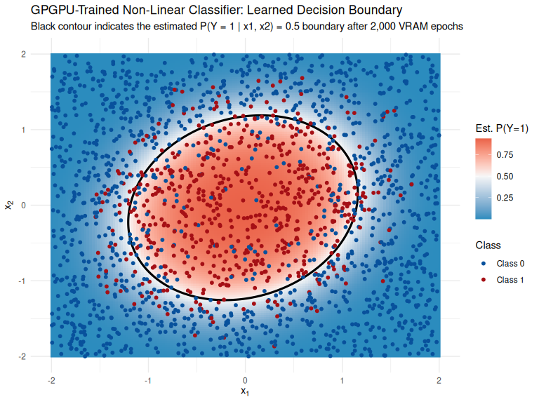

```r
library(ggplot2)

# Create a fine 2D grid over [-2, 2] x [-2, 2]
grid_seq  <- seq(-2, 2, length.out = 150)
grid_df   <- expand.grid(x1 = grid_seq, x2 = grid_seq)
grid_X    <- with(grid_df, cbind(x1, x2, x1^2, x2^2, x1 * x2))

# Compute predicted probabilities on the grid using our learned GPU parameters
grid_logit       <- as.vector(grid_X %*% fit_gpu$W) + fit_gpu$b
grid_df$prob_hat <- 1 / (1 + exp(-grid_logit))

obs_df <- data.frame(
  x1    = x1,
  x2    = x2,
  Class = factor(as.vector(y_obs), labels = c("Class 0", "Class 1"))
)

ggplot() +
  geom_raster(data = grid_df, aes(x = x1, y = x2, fill = prob_hat), lr = 0.75) +
  geom_contour(data = grid_df, aes(x = x1, y = x2, z = prob_hat),
               breaks = 0.5, color = "black", linewidth = 1.1) +
  geom_point(data = obs_df, aes(x = x1, y = x2, color = Class),
             lr = 0.55, size = 1.4) +
  scale_fill_gradient2(low = "#2b8cbe", mid = "#f7f7f7", high = "#e34a33",
                       midpoint = 0.5, name = "Est. P(Y=1)") +
  scale_color_manual(values = c("Class 0" = "#08519c", "Class 1" = "#a50f15")) +
  labs(
    title    = "GPGPU-Trained Non-Linear Classifier: Learned Decision Boundary",
    subtitle = "Black contour indicates the estimated P(Y = 1 | x1, x2) = 0.5 boundary after 2,000 VRAM epochs",
    x        = expression(x[1]),
    y        = expression(x[2])
  ) +
  theme_minimal() +
  theme(legend.position = "right")
```

# Part 5: Guidelines for Package Developers – Packaging Multi-Kernel JIT Pipelines

If you want to include custom GPGPU functionalities into your own redistributable R package, you can leverage `OpenCLeaR::oclFunction` inside an Immediately Invoked Function Expression (IIFE) using lexical scoping. This structural pattern provides an elegant on-the-fly caching mechanism: the expensive multi-kernel compilation step happens exactly once during the very first invocation, while subsequent training cycles instantly execute the pre-compiled VRAM pipeline.

To make a complex architecture like our multi-epoch neural classifier fully compliant with CRAN policies and `roxygen2` documentation pipelines, you can package it using the following blueprint:

```r
# 1. Register the hidden closure variable as a global to prevent CRAN check notes
if (getRversion() >= "2.15.1") {
  utils::globalVariables(".nn_classify_gpu_internal")
}

##' Enclosed Multi-Epoch Neural Network Training via OpenCL
##'
##' This function demonstrates how to wrap a complex OpenCLeaR JIT-compiled
##' multi-kernel pipeline into a standard R package function utilizing
##' a persistent closure cache.
##'
##' @name nn_classify_gpu
##' @param X_mat     A numeric design matrix containing input features.
##' @param W_mat     A numeric matrix representing initial layer weights.
##' @param b_vec     A numeric vector containing layer biases.
##' @param Y_mat     A numeric matrix containing observed target variables.
##' @param lr     The learning rate parameter for the SGD optimizer.
##' @param num_epochs The total number of training epochs to run entirely in VRAM.
##' @param ...        Arguments passed through to \code{\link{oclFunction}} like \code{verbose} or \code{force_float}.
##' @return A list containing the updated weight matrix \code{W}, the bias vector \code{b}, and predicted probabilities \code{Y_pred}.
##' @export
nn_classify_gpu <- (function() {
  # This variable remains persistent in the function's enclosing environment
  .nn_classify_gpu_internal <- NULL

  function(X_mat, W_mat, b_vec, Y_mat, lr, num_epochs, ...) {
    if (is.null(.nn_classify_gpu_internal)) {
      # The JIT compilation triggers ONLY on the first call
      .nn_classify_gpu_internal <<- OpenCLeaR::oclFunction(
        signature = signature(X       = "matrix",
                              W       = "matrix",
                              b       = "numeric",
                              Y_true  = "matrix",
                              lr      = "numeric",
                              epochs_in = "integer"),
        kernel_file    = "nn_stat_kernels.cl",
        interface_file = "nn_stat_rcpp.cpp",
        math_lib       = "libkernel.cl",
        ...
      )
    }
    # Direct execution of the cached binary pointer
    return(.nn_classify_gpu_internal(X = X_mat, W = W_mat, b = b_vec, Y_true = Y_mat, lr = lr, epochs_in = num_epochs))
  }
})()
```